# Replication of ‘Red, Rank, and Romance in Women Viewing Men’

*N* removed NAs: 2

*N* removed <18: 20

*N* total clean: 126

| Group | *N* | *M*<sub>age</sub> | *M*<sub>rating</sub> |
| --- | --- | --- | --- |
| Control | 63 | 20.79 | 7.49 |
| Experim | 63 | 20.87 | 6.25 |

**Main analysis results**

*t*(124) = 9.76, *p* < .001

# Replication of ‘Red, Rank, and Romance in Women Viewing Men’

Analysing Data, Spring 2020

# Methods

## Participants

Age of Participants by Condition

| Condition | *N* | % | *M*~age | *SD*<sub>age</sub> |
| --- | --- | --- | --- | --- |
| control | 63 | 50 | 20.79 | 1.86 |
| experimental | 63 | 50 | 20.87 | 1.84 |

## Design

An independent measures study was conducted to investigate if women would rate men’s attractiveness more highly if their image was placed on a red background as opposed to a white one. This was predicted to be the case due to red-attraction and red-status links that have previously been found. The independent measure in this study was background of the image, and whether it was red or white. White was the control condition and red was the experimental condition. Participants were shown the same image of a man, and the background was the only difference. The dependent measures for this was perceived attractiveness and this was assessed using three questions which were, “How attractive do you think this person is?”, “How pleasant is this person to look at?”, and “If I were to meet the person in this picture face to face, I would think he is attractive.” These were given on a 9 point scale where 1 was “not at all attractive” and 9 was “extremely attractive” and the scores were averaged to create a composite index. This composite score allowed us to complete a T-Test for statistical analyses.

# Results

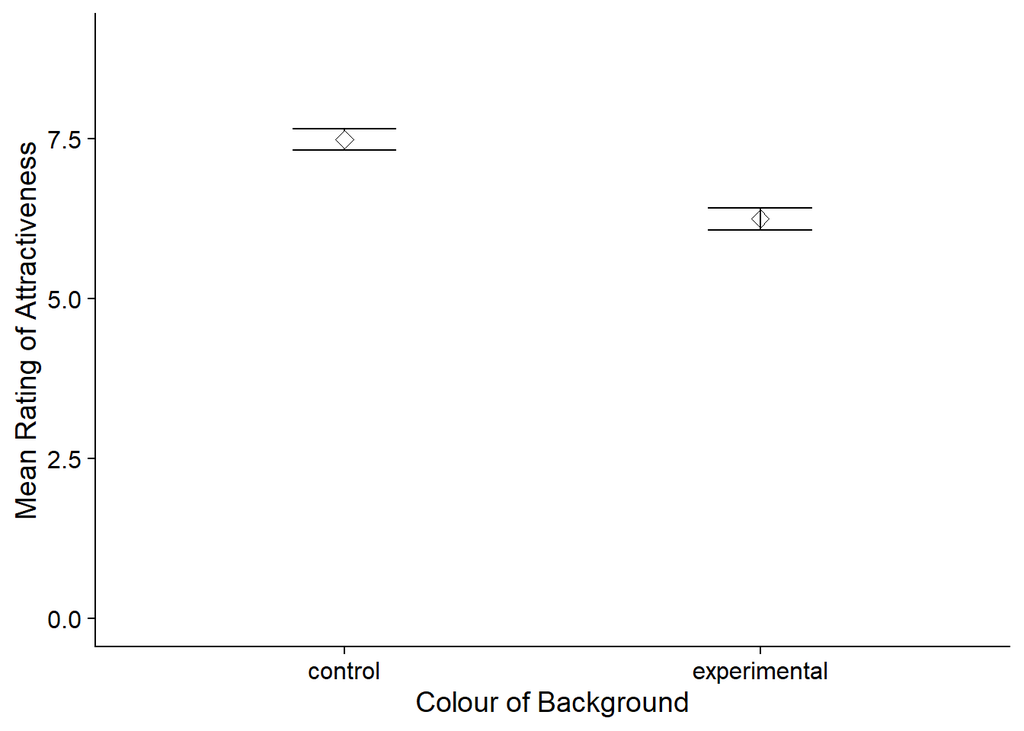

# Discussion

To summarise these results, this study has shown that a red background did not lead the participants to rate attractiveness more highly - which went against what was predicted and shown in the original study. Specifically, Elliot et al. (2010) found that when they placed the same image of a man on a white or red background, women were more likely to rate the red background image as more attractive. This could allude that the effect being investigated is rather turbulent, meaning that a red background may not be the cause for a higher rating as they suggested, this effect is more situation based.

Moving on, if we compare these findings to other research in this area, when investigating women’s ratings of attractiveness of men, articles are sporadic, as the majority has found this effect is more visible for red increasing mens’ attraction to women. For example, Lin (2014) found that by changing something as minimal as the colour of the laptop a woman is holding to red, rather than silver, black or blue, it increased the ratings that men gave their attractiveness. However, this effect did not occur in women as it did not change the way they perceived the same image.

It is difficult to argue if the red-attractiveness link in women observing men is real due to the disparity in the relationship being shown across research, and due to the fact that there is actually minimal research being conducted on this gender direction. Based on the conflicting research which has been undertaken, I would suggest that the colour red may not be the primary factor in increasing women’s attraction to men, but more research should be performed to determine what the most effective one is. Research has shown that men are more attracted to women associated with red as to them it implies increased sexual intent (Guéguen, 2011), so in the future we should also focus on the reasoning behind why women are not influenced by red quite as intensely as men, and why other factors produce more attraction.

Like any research, this study has its strengths and weaknesses. I believe that one limitation of this piece of research is it only investigated women’s attractiveness to men. In order to be more representative of the target population it would be necessary to investigate how red may influence women observing womens’ attractiveness, or men observing mens’ attractiveness. It is possible that these findings do not demonstrate the effect would have on their ratings. On the other hand, a strength of this research is that it’s replication of Elliot’s study is done well, meaning it provides important insight into issues that needed to be highlighted - specifically that their results may not be as strong as it was believed they were.

To conclude, this replication study has primarily brought light to the fact that further research needs to be conducted to determine how strong the relationship between red and male attractiveness is for women. We can take away that Elliot’s results are not as solid as they first appear and so more research is required into the area.

# References

Elliot, A. J., Kayser, D. N., Greitemeyer, T., Lichtenfeld, S., Gramzow, R. H. and Maier, M. (2010) Red, Rank, and Romance in Women Viewing Men. *Journal of Experimental Psychology, 139*(3), 399-417

Francis, G. (2013) Publication bias in “Red, rank, and romance in women viewing men,” by Elliot et al. (2010). *Journal of Experimental Psychology*, 142(1), 292-296

Guéguen, N. (2011) Colour and Women Attractiveness: When Red Clothed Women Are Perceived to have more Intense Sexual Intent. *The Journal of Social Psychology, 152*(3), 261-265

Hesslinger, V. M., Goldbach, L., & Carbon, C. (2015) Men in red: a reexamination of the red-attractiveness effect. *Psychonomic Bulletin & Review, 22*, 1142-1148

Lin., H. (2014) Red-coloured products enhance the attractiveness of women. *Displays, 35*(4), 202-205